# Example of using Python and R in a single notebook

## Using Multiple Kernels in one notebook

Multiple kernels can be used in a single a SoS notebook, with the SoS kernel being the super kernel that manages others. You can select kernel of a code cell using the language selection dropdown box at the top right corner or using SoS magics. Prompt areas of code cells belonging to different kernels are marked by different colors. You however might not be able to see the language dropdown box and colors as shown below if you are viewing the notebook with a viewer that does not recognize SoS kernel inormation.

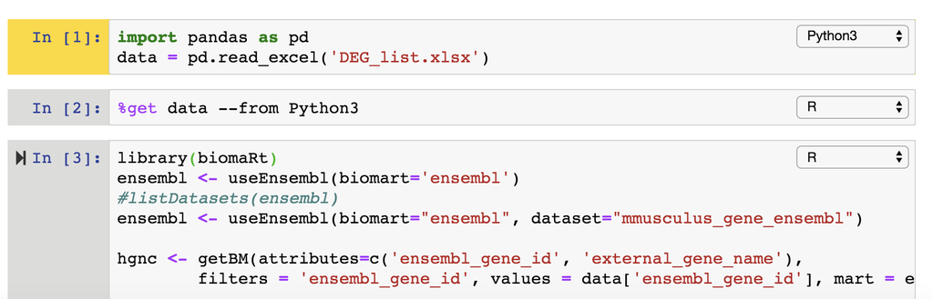

## An example of using Python and R in the same notebook

In this example we are converting an MS Excel file to csv format using Python `pandas` module. We then use `R` to annotate the gene names and draw some plot. The annotated data will be sent back to Python and write in excel format.

%preview DEG_list.xlsx

> DEG_list.xlsx (107.4 KiB):

Only the first 200 of the 1184 records are previewed. Use option --limit to set a new limit.

|  | ensembl_gene_id | baseMean | log2FoldChange | stat | pvalue | padj |
| --- | --- | --- | --- | --- | --- | --- |
| 0 | ENSMUSG00000042816 | 1686.121821 | 3.390100 | -28.589868 | 8.979679e-180 | 7.696034e-176 |
| 1 | ENSMUSG00000031635 | 358.401785 | 3.614133 | -21.471980 | 2.846325e-102 | 8.131476e-99 |
| 2 | ENSMUSG00000020838 | 551.448621 | 2.532469 | -18.878942 | 1.699551e-79 | 2.913201e-76 |
| 3 | ENSMUSG00000021765 | 597.716318 | 2.265537 | -17.571072 | 4.103412e-69 | 5.024042e-66 |
| 4 | ENSMUSG00000027907 | 3236.448003 | 1.306965 | -15.152852 | 7.254873e-52 | 6.908654e-49 |
| 5 | ENSMUSG00000026247 | 744.567819 | 1.999957 | -14.202403 | 8.852428e-46 | 6.897249e-43 |
| 6 | ENSMUSG00000030272 | 3322.013499 | 1.029098 | -13.056674 | 5.821582e-39 | 3.837990e-36 |
| 7 | ENSMUSG00000069793 | 317.952685 | 1.645894 | -12.727226 | 4.174068e-37 | 2.384924e-34 |
| 8 | ENSMUSG00000028494 | 4659.305199 | 1.051199 | -12.102120 | 1.029183e-33 | 5.188595e-31 |
| 9 | ENSMUSG00000059645 | 107.043454 | 1.777720 | -11.629145 | 2.930187e-31 | 1.287855e-28 |
| 10 | ENSMUSG00000026834 | 184.146231 | 1.576185 | -10.924823 | 8.771122e-28 | 3.496414e-25 |
| 11 | ENSMUSG00000069355 | 78.423674 | 1.896248 | -10.639715 | 1.947240e-26 | 7.101625e-24 |
| 12 | ENSMUSG00000024066 | 1207.689222 | 1.287185 | -10.412868 | 2.165954e-25 | 7.279729e-23 |
| 13 | ENSMUSG00000059173 | 2047.297734 | 1.290401 | -10.363868 | 3.620191e-25 | 1.128249e-22 |
| 14 | ENSMUSG00000044626 | 107.545685 | 1.479431 | -9.920675 | 3.384591e-23 | 9.833097e-21 |
| 15 | ENSMUSG00000029552 | 990.570372 | 0.942947 | -9.652480 | 4.798095e-22 | 1.305463e-19 |
| 16 | ENSMUSG00000000278 | 2246.095680 | 0.820046 | -9.477766 | 2.597862e-21 | 6.646262e-19 |
| 17 | ENSMUSG00000023067 | 3740.729262 | 0.935633 | -9.180521 | 4.290090e-20 | 1.035725e-17 |
| 18 | ENSMUSG00000021843 | 8362.210457 | 0.774680 | -8.942443 | 3.806602e-19 | 8.699862e-17 |
| 19 | ENSMUSG00000044258 | 622.236008 | 1.062715 | -8.723723 | 2.692001e-18 | 5.840961e-16 |
| 20 | ENSMUSG00000020205 | 1313.876243 | 1.029466 | -8.587091 | 8.919931e-18 | 1.842127e-15 |
| 21 | ENSMUSG00000037280 | 336.544531 | 1.119365 | -8.342550 | 7.270520e-17 | 1.432460e-14 |
| 22 | ENSMUSG00000027556 | 365.075577 | 1.161261 | -8.021451 | 1.045036e-15 | 1.968457e-13 |
| 23 | ENSMUSG00000031799 | 7421.027362 | 0.624473 | -7.913186 | 2.508835e-15 | 4.526730e-13 |
| 24 | ENSMUSG00000036905 | 1706.843435 | 0.709253 | -7.846027 | 4.294230e-15 | 7.435091e-13 |
| 25 | ENSMUSG00000044667 | 545.471721 | 0.867126 | -7.784684 | 6.988793e-15 | 1.163057e-12 |
| 26 | ENSMUSG00000021125 | 389.752252 | 0.884616 | -7.713982 | 1.219520e-14 | 1.953626e-12 |
| 27 | ENSMUSG00000025351 | 5138.213127 | 0.601866 | -7.593747 | 3.107838e-14 | 4.799230e-12 |
| 28 | ENSMUSG00000032666 | 5242.276743 | 0.592958 | -7.454353 | 9.030998e-14 | 1.346090e-11 |
| 29 | ENSMUSG00000019866 | 554.456799 | 0.850782 | -7.439136 | 1.013460e-13 | 1.459809e-11 |

[output cut: 170 more lines]

We can then go to a R kernel and get `data` from the Python3 kernel

%preview annotated

> annotated:

| ensembl_gene_id | baseMean | log2FoldChange | stat | pvalue | padj | external_gene_name |
| --- | --- | --- | --- | --- | --- | --- |
| ENSMUSG00000000214 | 4138.211600 | -0.6104918 | 6.070828 | 1.272524e-09 | 1.136059e-07 | Th |
| ENSMUSG00000000278 | 2246.095680 | 0.8200463 | -9.477766 | 2.597862e-21 | 6.646262e-19 | Scpep1 |
| ENSMUSG00000000308 | 9818.688762 | -0.2338556 | 2.821715 | 4.776759e-03 | 3.975285e-02 | Ckmt1 |
| ENSMUSG00000000320 | 155.787128 | 0.2876111 | -1.986710 | 4.695454e-02 | 1.806179e-01 | Alox12 |
| ENSMUSG00000000416 | 1155.098102 | 0.5420341 | -4.956080 | 7.192943e-07 | 3.368695e-05 | Cttnbp2 |
| ENSMUSG00000000420 | 3554.753276 | 0.2553115 | -3.232391 | 1.227588e-03 | 1.514909e-02 | Galnt1 |
| ENSMUSG00000000627 | 4476.218886 | 0.2718751 | -2.310253 | 2.087415e-02 | 1.067084e-01 | Sema4f |
| ENSMUSG00000000628 | 319.764340 | 0.4280945 | -2.946737 | 3.211462e-03 | 2.997037e-02 | Hk2 |
| ENSMUSG00000000682 | 484.846830 | 0.6266664 | -4.680273 | 2.864929e-06 | 1.121181e-04 | Cd52 |
| ENSMUSG00000000730 | 7.627173 | 0.2362571 | -2.682550 | 7.306328e-03 | NA | Dnmt3l |
| ENSMUSG00000000743 | 4563.611985 | -0.2508448 | 2.641865 | 8.245084e-03 | 5.726458e-02 | Chmp1a |
| ENSMUSG00000000751 | 3874.653413 | -0.2331316 | 2.954892 | 3.127784e-03 | 2.945788e-02 | Rpa1 |
| ENSMUSG00000000794 | 77.932213 | -0.2945470 | 2.003576 | 4.511548e-02 | 1.763317e-01 | Kcnn3 |
| ENSMUSG00000001025 | 17006.747340 | -0.2574028 | 2.833605 | 4.602618e-03 | 3.874925e-02 | S100a6 |
| ENSMUSG00000001280 | 2383.288580 | 0.2246021 | -2.467233 | 1.361619e-02 | 8.035354e-02 | Sp1 |
| ENSMUSG00000001333 | 1162.464914 | -0.2255600 | 2.420478 | 1.550010e-02 | 8.749375e-02 | Sync |
| ENSMUSG00000001349 | 148.230383 | 0.6607889 | -4.841966 | 1.285610e-06 | 5.536844e-05 | Cnn1 |
| ENSMUSG00000001380 | 7918.922528 | 0.1824277 | -2.565276 | 1.030939e-02 | 6.648355e-02 | Hars |
| ENSMUSG00000001415 | 4248.668568 | -0.2422268 | 2.539732 | 1.109373e-02 | 6.998002e-02 | Smg5 |
| ENSMUSG00000001436 | 1263.258383 | -0.2358637 | 2.236040 | 2.534914e-02 | 1.219163e-01 | Slc19a1 |
| ENSMUSG00000001700 | 311.687287 | 0.3393851 | -2.773708 | 5.542144e-03 | 4.412350e-02 | Gramd3 |
| ENSMUSG00000001755 | 1499.568213 | -0.2106140 | 2.275383 | 2.288294e-02 | 1.134287e-01 | Coasy |
| ENSMUSG00000001774 | 4364.573704 | 0.2430831 | -2.494867 | 1.260045e-02 | 7.610440e-02 | Chordc1 |
| ENSMUSG00000001847 | 12823.805954 | 0.1778602 | -2.162103 | 3.061020e-02 | 1.377861e-01 | Rac1 |
| ENSMUSG00000001865 | 509.589410 | 0.4566291 | -3.556262 | 3.761693e-04 | 6.278402e-03 | Cpa3 |
| ENSMUSG00000001870 | 762.307906 | 0.3557346 | -3.267733 | 1.084126e-03 | 1.391985e-02 | Ltbp1 |
| ENSMUSG00000001909 | 1565.248475 | -0.2889704 | 3.250489 | 1.152069e-03 | 1.453099e-02 | Trmt1 |
| ENSMUSG00000001911 | 1633.174086 | 0.2427731 | -2.141406 | 3.224132e-02 | 1.423618e-01 | Nfix |
| ENSMUSG00000001924 | 24575.966751 | -0.2108731 | 2.320610 | 2.030790e-02 | 1.048171e-01 | Uba1 |
| ENSMUSG00000001964 | 1547.844892 | 0.1863153 | -2.199904 | 2.781371e-02 | 1.294123e-01 | Emd |
| ⋮ | ⋮ | ⋮ | ⋮ | ⋮ | ⋮ | ⋮ |
| ENSMUSG00000094335 | 20.686622 | 0.42640562 | -4.003223 | 6.248541e-05 | 0.0015043012 | Igkv1-117 |
| ENSMUSG00000094546 | 64.161416 | 0.07526115 | -2.260089 | 2.381575e-02 | 0.1167772425 | Ighv1-26 |
| ENSMUSG00000094626 | 22.445892 | 0.27654076 | -2.095705 | 3.610832e-02 | 0.1530875042 | Tmem121b |
| ENSMUSG00000094732 | 3.633133 | 0.14851581 | -3.182034 | 1.462445e-03 | NA | 1500015L24Rik |
| ENSMUSG00000094797 | 18.370489 | 0.35850328 | -4.275262 | 1.909123e-05 | 0.0005651862 | Igkv6-15 |
| ENSMUSG00000095028 | 17.748802 | 0.22071387 | -1.964435 | 4.947964e-02 | 0.1864842910 | Sirpb1b |
| ENSMUSG00000095362 | 1014.129481 | 0.33930276 | -2.507800 | 1.214854e-02 | 0.0741588770 | Gm14325 |
| ENSMUSG00000095918 | 8.390640 | 0.23178587 | -3.035931 | 2.397942e-03 | NA | Gm5861 |
| ENSMUSG00000096403 | 29.135621 | -0.24779867 | 3.079376 | 2.074344e-03 | 0.0222366002 | Gm9825 |
| ENSMUSG00000096459 | 14.669469 | 0.21227296 | -2.909286 | 3.622557e-03 | 0.0327782193 | Ighv9-3 |
| ENSMUSG00000096490 | 51.152757 | 0.07584179 | -3.109132 | 1.876381e-03 | 0.0207369783 | Igkv10-94 |
| ENSMUSG00000096715 | 16.382006 | 0.27253764 | -3.301588 | 9.613918e-04 | 0.0128043637 | Igkv3-4 |
| ENSMUSG00000096780 | 124.903362 | -0.34382425 | 2.328241 | 1.989932e-02 | 0.1034559469 | Tmem181b-ps |
| ENSMUSG00000096847 | 2633.169634 | -0.42194215 | 3.709991 | 2.072666e-04 | 0.0039562996 | Tmem151b |
| ENSMUSG00000096931 | 35.233861 | 0.53532942 | -3.994924 | 6.471497e-05 | 0.0015406656 | Gm26656 |
| ENSMUSG00000096965 | 2.868267 | 0.11022564 | -2.252913 | 2.426467e-02 | NA | 3300005D01Rik |
| ENSMUSG00000097047 | 29.021538 | 0.30269031 | -2.223309 | 2.619498e-02 | 0.1244824421 | 1110020A21Rik |
| ENSMUSG00000097180 | 53.448333 | 0.32390828 | -2.222511 | 2.624878e-02 | 0.1245999453 | 2700038G22Rik |
| ENSMUSG00000097357 | 107.212979 | 0.40217004 | -2.821819 | 4.775216e-03 | 0.0397528498 | Gm16793 |
| ENSMUSG00000097375 | 196.255308 | 0.37877733 | -2.808336 | 4.979819e-03 | 0.0409592491 | 6720427I07Rik |
| ENSMUSG00000097404 | 101.130734 | -0.31233829 | 2.122148 | 3.382527e-02 | 0.1464508726 | Gm10814 |
| ENSMUSG00000097466 | 145.564341 | 0.38068267 | -2.630043 | 8.537396e-03 | 0.0584890902 | D430036J16Rik |
| ENSMUSG00000097576 | 15.619078 | 0.25088628 | -2.140711 | 3.229731e-02 | 0.1424989027 | D930030I03Rik |
| ENSMUSG00000097622 | 63.268414 | -0.47408131 | 3.199273 | 1.377745e-03 | 0.0165030907 | A330033J07Rik |
| ENSMUSG00000097645 | 11.668458 | 0.20785568 | -2.153071 | 3.131308e-02 | NA | Gm26863 |
| ENSMUSG00000097908 | 219.536423 | -0.28505132 | 2.258253 | 2.392987e-02 | 0.1171278958 | 4933404O12Rik |
| ENSMUSG00000098276 | 6.499809 | 0.22822696 | -3.102306 | 1.920195e-03 | NA | Mir6358 |
| ENSMUSG00000098318 | 16.721908 | 0.24041191 | -2.126204 | 3.348625e-02 | 0.1454238144 | Lockd |
| ENSMUSG00000098482 | 192.980606 | 0.35082491 | -2.511948 | 1.200668e-02 | 0.0737129485 | Mir6363 |
| ENSMUSG00000098973 | 3337.553280 | 0.48588812 | -3.340461 | 8.363935e-04 | 0.0114601289 | Mir6236 |

We can also draw some plot and preview the result. Instead of displaying the result directly in the notebook, the R code saves the image in a file (so that it can be shared with others separately) and use the `%preview` magic to display it in the notebook.

**pdf:** 2

%preview result.png

> result.png (22.0 KiB):

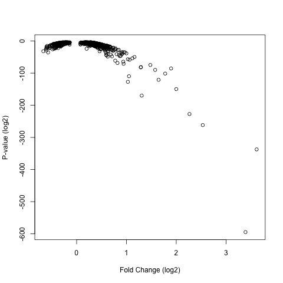

## Session Info

As a good practice, a `%sessioninfo` magic should be used at the end of all SoS Notebooks to show the session information of all kernels involved.

SoS

SoS Version

```
0.16.12
```

Python3

Kernel

```
python3
```

Language

```
Python3
```

Version

```
3.6.6 |Anaconda, Inc.| (default, Jun 28 2018, 11:07:29)
[GCC 4.2.1 Compatible Clang 4.0.1 (tags/RELEASE_401/final)]
```

pandas

```
0.23.4
```

R

Kernel

```
ir
```

Language

```
R
```

[session information not shown]